# Lab3_answers

sbsambado

1/16/2021

# Answers for Lab 3

**Question 1** (3 points: 1 point for code, 1 point for correctly answering each answer)

**Question 2** (4 points: 1 point for code, 1 code for correctly answering each question)

- 1. Squaring the data only scaled the data, but did nothing about changing the distribution (“increasing the right skew”). Log-transforming the data changed the distribution (“decreased the right skew of the data”).
- 2. The log-transformed data looks more normal.
- 3. The variable `num_flowers` can be 0 because it is a count. However the log of 0 is not a number; it is negative infinity. Therefore, we need to add 1 to all values in the column to scale the data.

Squaring zero still gives us zero.

Technically, we would not need to add 1 if we log-transformed `dand_rosette_diam_cm` because measures are continuous variables that are always greater than 0. However, in our data set there actually are a few `dand_rosette_diam_cm` measures that are 0 due to mis-recording.

**Question 3** (3 points: 1 point for code and 1 point correctly answering each question)

- 1. As we increase the distance from the nearest tree we see an increase in the percent cover. However, the linear trend line is not a good representation of this trend. The trend looks distinctly non-linear and there is substantial variation in the data. Just because R fitted a linear trend line doesn’t mean that a line is the best fit. Even looking just looking at the slope of the line, we can tell it’s a small relationship. Thus indicating that there is a weak to possibly no linear relationship.
- 2. The explanatory variable is `dist_from_tree_m` and the response variable is `percent_cover`.

*Notes*

- ALL HOMEWORK SHOULD BE SUBMITTED AS A KNITTED HOMEWORK FILE (.PDF or .HTML)
  - -1.0 point for not PDF or HTML
- - point for 1 day late
- Take the time to nail in homework format since it’s still early in course
  - -.25 point if code is not annotated
  - -.25 point if answers are not in complete sentences
  - -.25 point if code does not seem adequate to answer question
- no credit for corrupted/non-working file

# Some potential code to answer questions

## Question 1

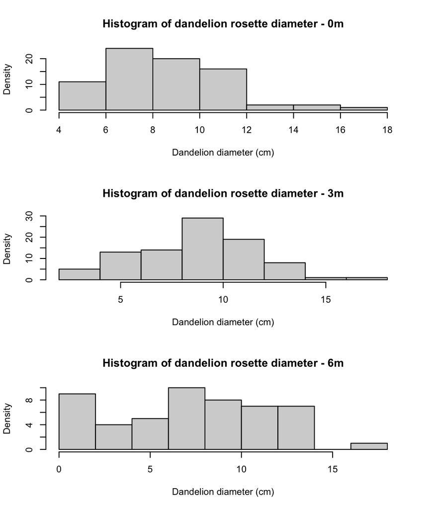

```r
plant <- read.csv("plant_data.csv")

# Make a histogram of dandelion rosette diameter - using basic R plotting code
par(mfrow=c(3,1))
hist(plant$dand_rosette_diam_cm[plant$dist_from_edge_m == "0.0m"], xlab="Dandelion diameter (cm)", ylab="Density", main = "Histogram of dandelion rosette diameter - 0m")
hist(plant$dand_rosette_diam_cm[plant$dist_from_edge_m == "3.0m"], xlab="Dandelion diameter (cm)", ylab="Density", main = "Histogram of dandelion rosette diameter - 3m")
hist(plant$dand_rosette_diam_cm[plant$dist_from_edge_m == "6.0m"], xlab="Dandelion diameter (cm)", ylab="Density", main = "Histogram of dandelion rosette diameter - 6m")
```

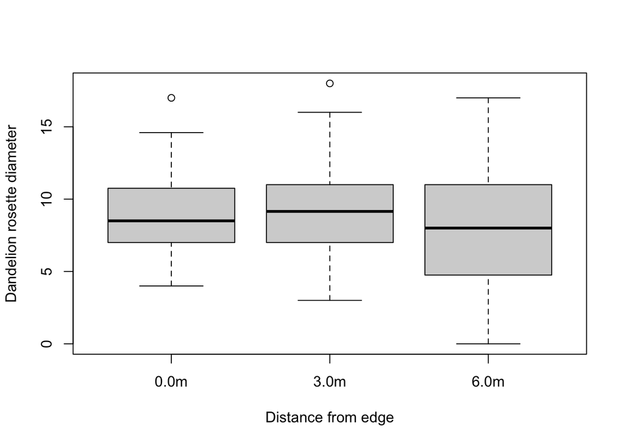

```r
# Make a boxplot of dandelion rosette diameter
boxplot(dand_rosette_diam_cm ~ dist_from_edge_m, plant, xlab="Distance from edge",
        ylab="Dandelion rosette diameter")
```

## Question 2

```r
plant$log_num_flowers = log(plant$num_flowers + 1)
plant$num_flowers_sq = plant$num_flowers^2
```

Plotting the 3 histograms

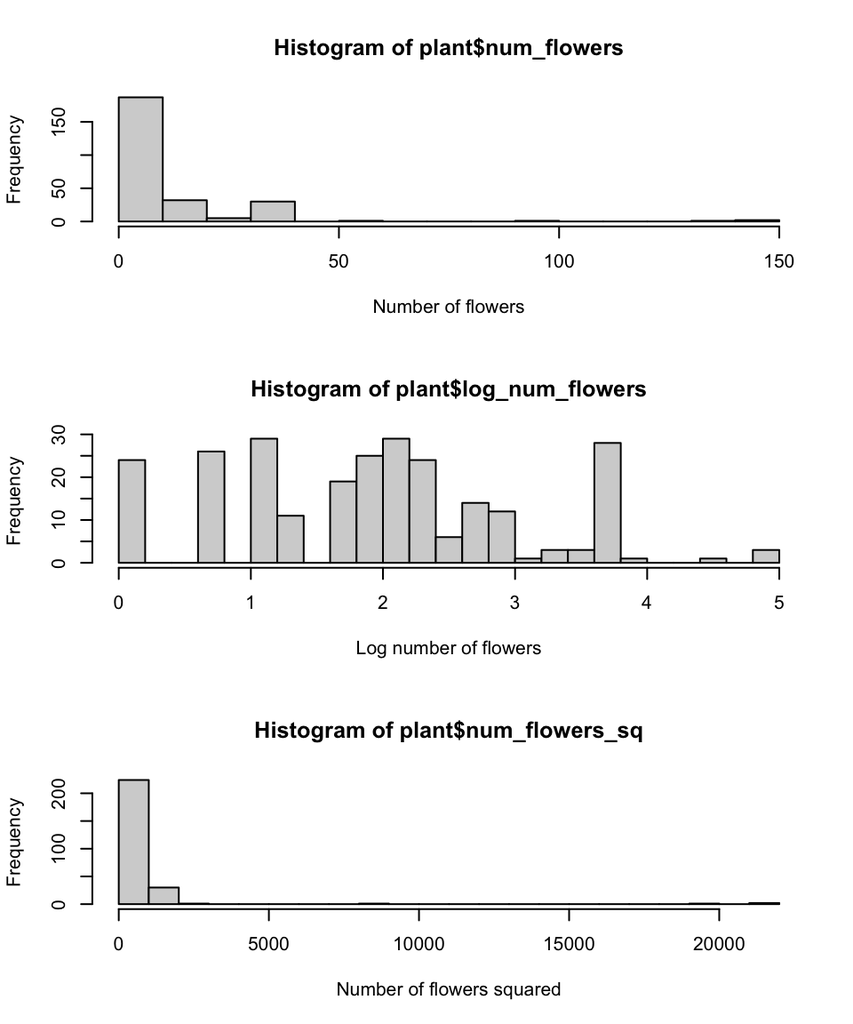

```r
# using using basic R plotting code
par(mfrow=c(3,1))
hist(plant$num_flowers, xlab="Number of flowers", breaks=20)
hist(plant$log_num_flowers, xlab="Log number of flowers", breaks=20)
hist(plant$num_flowers_sq, xlab="Number of flowers squared", breaks=20)
```

## Question 3

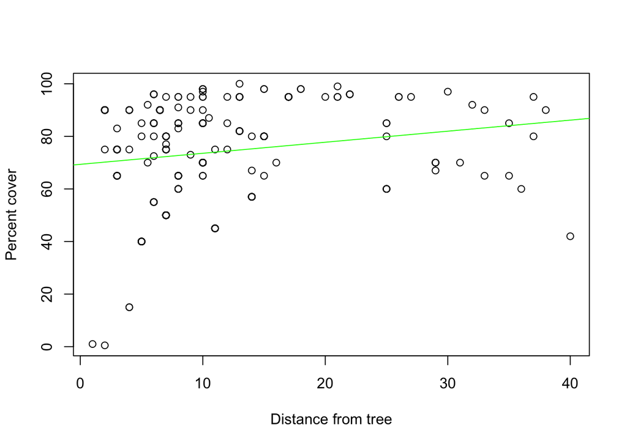

```r
# how you would code this in R
plot(plant$percent_cover ~ plant$dist_from_tree_m, xlab="Distance from tree", ylab="Percent cover")

fit <- lm(plant$percent_cover ~ plant$dist_from_tree_m, data=plant)
abline(fit,col="green")
```